# Covid Dream Team

Angela, Erick, Milena, Charivel, Daniel

2023-04-10

# Librerias y Carga de Archivos

```r
#Base de datos creada en actividad 1
df2 = read.csv('~/Downloads/df2.csv')
covid1 = read.csv('~/Downloads/spda_covid19/covid1.csv')
```

```r
mapasf = read_sf("~/Downloads/spda_covid19/shp_mx_mpios/mx_mpios.shp")
mapasf = geo_join(mapasf, df2, 'IDUNICO','cve_ent', how = 'inner')
maparsp <-readShapePoly("~/Downloads/spda_covid19/shp_mx_mpios/mx_mpios.shp",IDvar="IDUNICO",proj4string=CRS("+proj=longlat")) ### reads data from a polygon shapefile.
maparsp = geo_join(maparsp, df2, 'IDUNICO','cve_ent', how = 'inner')
maparsp
```

```
## class       : SpatialPolygonsDataFrame
## features    : 2456
## extent      : -118.4076, -86.71041, 14.5321, 32.71865  (xmin, xmax, ymin, ymax)
## crs         : +proj=longlat +datum=WGS84 +no_defs
## variables   : 14
## names       : CODELAG, CVE_ENT, IDUNICO,    X, cve_ent,       tasa_covid, inclusion_fin_2019, popden2020, porcentaje_pob_pobreza_ext, porcentaje_pob_pobreza, porcentaje_pob_acceso_ss, pob_6.14_no_edu,        entidad, cant_hosp
## min values  :       1,       1,    1001,    1,    1001,                0,                  0,      0.156,                          0,                 0.0545,                   0.2203,               0, Aguascalientes,         1
## max values  :    2456,      32,   32058, 2457,   32058, 546.742148653594,              10.68,   56489.74,                     0.8445,                 0.9965,                   0.9699,           38.56,      Zacatecas,      5214
```

# Modelos

## Regresion NO Espacial

```r
model <- lm(log1p(tasa_covid) ~ log(popden2020) + log1p(inclusion_fin_2019) + porcentaje_pob_pobreza + log1p(porcentaje_pob_pobreza_ext) + log1p(pob_6.14_no_edu) + porcentaje_pob_acceso_ss + cant_hosp, data = df2)

summary(model)
```

```
##
## Call:
## lm(formula = log1p(tasa_covid) ~ log(popden2020) + log1p(inclusion_fin_2019) +
##     porcentaje_pob_pobreza + log1p(porcentaje_pob_pobreza_ext) +
##     log1p(pob_6.14_no_edu) + porcentaje_pob_acceso_ss + cant_hosp,
##     data = df2)
##
## Residuals:
##     Min      1Q  Median      3Q     Max
## -3.7426 -0.5385  0.0530  0.6144  3.0842
##
## Coefficients:
##                                     Estimate Std. Error t value Pr(>|t|)
## (Intercept)                        4.644e+00  1.409e-01  32.959  < 2e-16 ***
## log(popden2020)                    1.491e-01  1.249e-02  11.939  < 2e-16 ***
## log1p(inclusion_fin_2019)          4.280e-01  5.618e-02   7.618 3.66e-14 ***
## porcentaje_pob_pobreza            -2.446e+00  2.169e-01 -11.274  < 2e-16 ***
## log1p(porcentaje_pob_pobreza_ext) -2.235e+00  3.243e-01  -6.892 6.99e-12 ***
## log1p(pob_6.14_no_edu)            -8.894e-02  4.503e-02  -1.975   0.0484 *
## porcentaje_pob_acceso_ss          -1.684e-01  1.986e-01  -0.848   0.3964
## cant_hosp                          1.534e-05  6.508e-05   0.236   0.8136
## ---
## Signif. codes:  0 '***' 0.001 '**' 0.01 '*' 0.05 '.' 0.1 ' ' 1
##
## Residual standard error: 0.945 on 2441 degrees of freedom
##   (8 observations deleted due to missingness)
## Multiple R-squared:  0.5078, Adjusted R-squared:  0.5064
## F-statistic: 359.8 on 7 and 2441 DF,  p-value: < 2.2e-16
```

En este modelo se realizaron transformaciones logaritmicas para evitar el sesgo presentado por varias variables, cabe destacar que en la mayoría se uso una transformación **log1p** dado que contaban con valores muy cercanos a 0, y esto ocasionaba que la función no corriera. Vemos que la mayoría son significativas y que la población e inclusión financiera afectan positivamente en los casos de covid, mientras a mayor pobreza, pobreza extrema y falta de educación se reducen los casos de covid.

```r
errorml = sqrt(mean(model$residuals^2))
errorml
```

```
## [1] 0.9434254
```

## Modelo de Regresion Espacial

### Spatial Error Model

```r
map.link = poly2nb(maparsp, queen=T)
map.linkW = nb2listw(map.link, style = "W")
```

```r
maparsp1 =  subset(maparsp, select = -entidad)
spatial_error_model <- errorsarlm(log1p(tasa_covid) ~ log(popden2020) + log1p(inclusion_fin_2019) + porcentaje_pob_pobreza + log1p(porcentaje_pob_pobreza_ext) + log1p(pob_6.14_no_edu) + porcentaje_pob_acceso_ss + cant_hosp, data = maparsp1, map.linkW, method = "Matrix")
summary(spatial_error_model)
```

```
##
## Call:
## errorsarlm(formula = log1p(tasa_covid) ~ log(popden2020) + log1p(inclusion_fin_2019) +
##     porcentaje_pob_pobreza + log1p(porcentaje_pob_pobreza_ext) +
##     log1p(pob_6.14_no_edu) + porcentaje_pob_acceso_ss + cant_hosp,
##     data = maparsp1, listw = map.linkW, method = "Matrix")
##
## Residuals:
##       Min        1Q    Median        3Q       Max
## -3.768925 -0.425088  0.050473  0.487545  3.367039
##
## Type: error
## Coefficients: (asymptotic standard errors)
##                                      Estimate  Std. Error z value  Pr(>|z|)
## (Intercept)                        4.1922e+00  1.7316e-01 24.2101 < 2.2e-16
## log(popden2020)                    1.5145e-01  1.7290e-02  8.7596 < 2.2e-16
## log1p(inclusion_fin_2019)          4.1550e-01  4.8610e-02  8.5476 < 2.2e-16
## porcentaje_pob_pobreza            -2.1684e+00  2.4084e-01 -9.0033 < 2.2e-16
## log1p(porcentaje_pob_pobreza_ext) -2.1919e+00  3.6422e-01 -6.0181 1.764e-09
## log1p(pob_6.14_no_edu)            -7.0167e-03  4.5555e-02 -0.1540    0.8776
## porcentaje_pob_acceso_ss          -8.5646e-02  2.0943e-01 -0.4090    0.6826
## cant_hosp                          4.1481e-05  5.5654e-05  0.7453    0.4561
##
## Lambda: 0.57978, LR test value: 558.53, p-value: < 2.22e-16
## Approximate (numerical Hessian) standard error: 0.021196
##     z-value: 27.354, p-value: < 2.22e-16
## Wald statistic: 748.23, p-value: < 2.22e-16
##
## Log likelihood: -3053.092 for error model
## ML residual variance (sigma squared): 0.6608, (sigma: 0.8129)
## Number of observations: 2449
## Number of parameters estimated: 10
## AIC: 6126.2, (AIC for lm: 6682.7)
```

Este modelo se puede considerar significativo. Aunque la maginitud y la significacia cambiaran es seguro decir que la a mayor población y mayor inclusión financiera mayores tasas de covid, y a mayor pobreza y pobreza extrema menores casos de covid.

```r
sqrt(mean((maparsp1$tasa_covid - spatial_error_model$fitted.values)^2))
```

```
## [1] 77.59462
```

### Spatial Autorregressive Model

```r
spatial_lag_model <- lagsarlm(log1p(tasa_covid) ~ log(popden2020) + log1p(inclusion_fin_2019) + porcentaje_pob_pobreza + log1p(porcentaje_pob_pobreza_ext) + log1p(pob_6.14_no_edu) + porcentaje_pob_acceso_ss + cant_hosp, data = maparsp1, map.linkW, method = "Matrix")
summary(spatial_lag_model)
```

```
##
## Call:
## lagsarlm(formula = log1p(tasa_covid) ~ log(popden2020) + log1p(inclusion_fin_2019) +
##     porcentaje_pob_pobreza + log1p(porcentaje_pob_pobreza_ext) +
##     log1p(pob_6.14_no_edu) + porcentaje_pob_acceso_ss + cant_hosp,
##     data = maparsp1, listw = map.linkW, method = "Matrix")
##
## Residuals:
##       Min        1Q    Median        3Q       Max
## -3.645052 -0.439032  0.049354  0.498262  3.109502
##
## Type: lag
## Coefficients: (numerical Hessian approximate standard errors)
##                                      Estimate  Std. Error z value  Pr(>|z|)
## (Intercept)                        2.4669e+00  1.4929e-01 16.5237 < 2.2e-16
## log(popden2020)                    9.5911e-02  1.1079e-02  8.6571 < 2.2e-16
## log1p(inclusion_fin_2019)          4.7631e-01  4.9103e-02  9.7004 < 2.2e-16
## porcentaje_pob_pobreza            -1.3660e+00  1.9476e-01 -7.0140 2.317e-12
## log1p(porcentaje_pob_pobreza_ext) -1.3151e+00  2.8512e-01 -4.6124 3.981e-06
## log1p(pob_6.14_no_edu)            -1.1533e-01  3.9886e-02 -2.8915  0.003835
## porcentaje_pob_acceso_ss          -1.5867e-01  1.7806e-01 -0.8911  0.372899
## cant_hosp                          3.6467e-05  5.8670e-05  0.6216  0.534230
##
## Rho: 0.48893, LR test value: 526.94, p-value: < 2.22e-16
## Approximate (numerical Hessian) standard error: 0.019197
##     z-value: 25.469, p-value: < 2.22e-16
## Wald statistic: 648.66, p-value: < 2.22e-16
##
## Log likelihood: -3068.884 for lag model
## ML residual variance (sigma squared): 0.6846, (sigma: 0.82741)
## Number of observations: 2449
## Number of parameters estimated: 10
## AIC: 6157.8, (AIC for lm: 6682.7)
```

Este modelo coincide en la significancia de variables y direcciones, lo que cambia es la manitud de los estimados, siendo este modelo más conservador.

```r
sqrt(mean((maparsp1$tasa_covid - spatial_lag_model$fitted.values)^2))
```

```
## [1] 77.57457
```

## Machine Learning Model Random Forest

```r
set.seed(27812)

covid1 <- na.omit(covid1)

sample <- sample(c(TRUE, FALSE), nrow(covid1), replace=TRUE, prob=c(0.7,0.3))
train  <- covid1[sample, ]
test   <- covid1[!sample, ]


random_forest <- randomForest(log1p(tasa_covid) ~ ., data=train, proximity=TRUE)
print(random_forest)
```

```
##
## Call:
##  randomForest(formula = log1p(tasa_covid) ~ ., data = train, proximity = TRUE)
##                Type of random forest: regression
##                      Number of trees: 500
## No. of variables tried at each split: 3
##
##           Mean of squared residuals: 0.6757766
##                     % Var explained: 63.11
```

```r
rf_prediction_test_data <-predict(random_forest,test)

rmse(rf_prediction_test_data, test$tasa_covid)
```

```
## [1] 75.19947
```

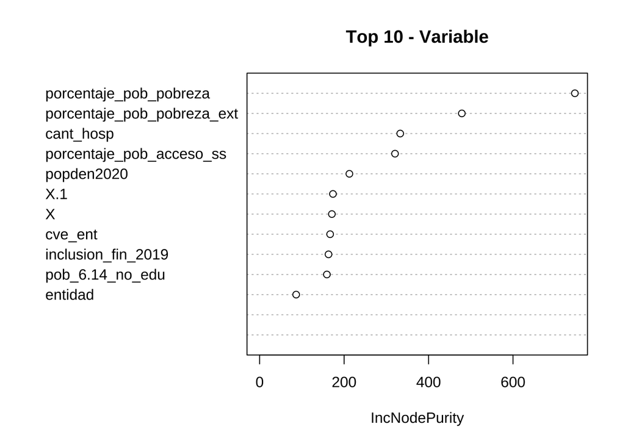

```r
varImpPlot(random_forest, n.var = 13, main = "Top 10 - Variable") # It displays a variable importance plot from the random forest model.
```

```r
importance(random_forest)
```

```
##                            IncNodePurity
## X.1                            173.64383
## X                              171.09280
## cve_ent                        166.93712
## inclusion_fin_2019             163.14633
## popden2020                     212.51920
## porcentaje_pob_pobreza_ext     478.80476
## porcentaje_pob_pobreza         746.50182
## porcentaje_pob_acceso_ss       320.58622
## pob_6.14_no_edu                159.28323
## entidad                         86.49746
## cant_hosp                      332.91067
```

Podemos ver la importancia de las diferentes variables mostradas en el modelo